# TP02- Preprocesamiento con R

#### b. Analice los resultados encontrados. Compare los mismos realizando gráficos sobre los atributos resultantes en cada caso.

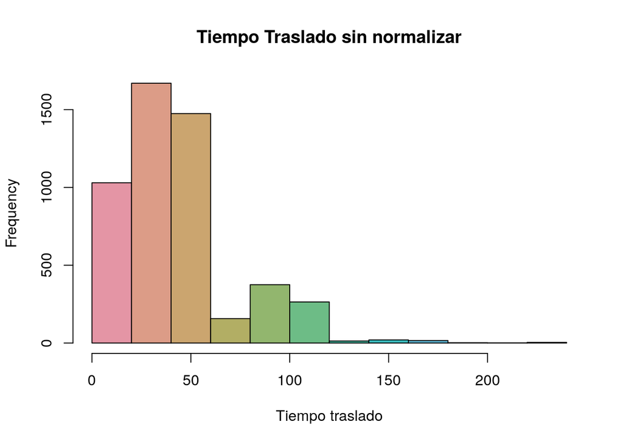

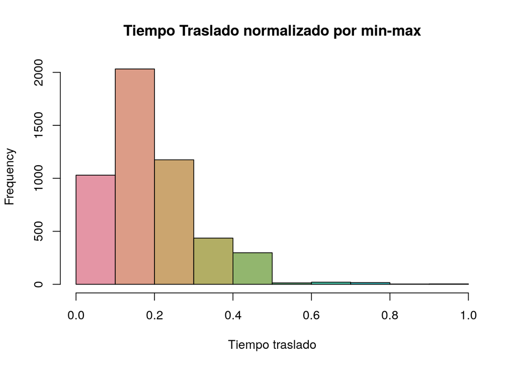

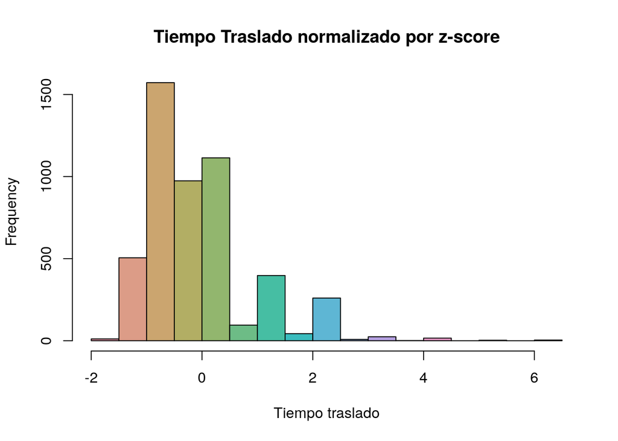

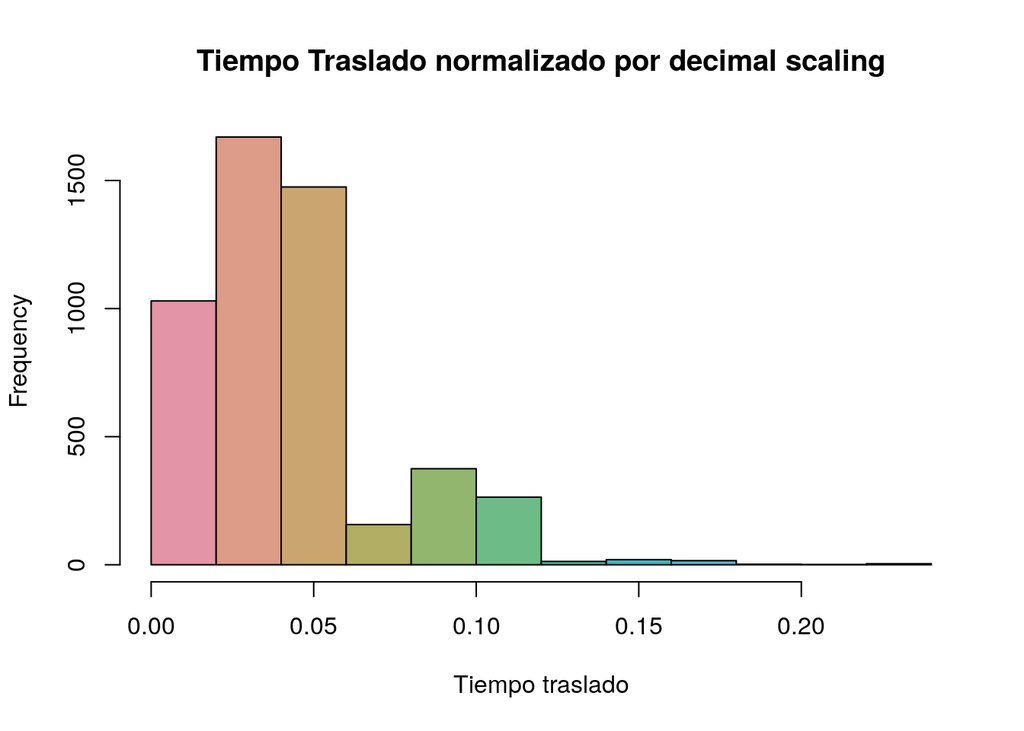

La técnica de normalización mantiene de forma apropiada la distribución original de la variable. Todos los histogramas presentan una distribucion similar, no normal, con asimetría positiva, es decir, mayor cantidad de valores bajos.

Además, se pueden observar los outliers, en la parte derecha de todos los histogramas.

La normalización mediante decimal-scaling es la que mantiene mejor el comportamiento de la distribución original, esto se debe a que estamos dividiendo a todos los valores de la distribución por una constante.